# Dimensionality reduction techniques

*Because analysing and visualising tens of dimensions is much more difficult, it is often useful to reduce the number of dimensions by merging correlating variables together. In this analysis we conduct a* Principle Component Analysis _ and a_ Multiple Correspondence Analysis_._

## Data overview

The data we use here was created as part of the [UN’s Human Development Programme](http://hdr.undp.org/en/content/human-development-index-hdi), reflecting the Human Development Index (HDI), Gross National Income, and variables such as the expected education level or percentage of women in labor in different countries. For an overview, the variables are:

```
## 'data.frame':    155 obs. of  8 variables:
##  $ eduratio: num  1.007 0.997 0.983 0.989 0.969 ...
##  $ labratio: num  0.891 0.819 0.825 0.884 0.829 ...
##  $ exped   : num  17.5 20.2 15.8 18.7 17.9 16.5 18.6 16.5 15.9 19.2 ...
##  $ lifexp  : num  81.6 82.4 83 80.2 81.6 80.9 80.9 79.1 82 81.8 ...
##  $ gni     : int  64992 42261 56431 44025 45435 43919 39568 52947 42155 32689 ...
##  $ matmor  : int  4 6 6 5 6 7 9 28 11 8 ...
##  $ adbirth : num  7.8 12.1 1.9 5.1 6.2 3.8 8.2 31 14.5 25.3 ...
##  $ parlperc: num  39.6 30.5 28.5 38 36.9 36.9 19.9 19.4 28.2 31.4 ...
```

i.e.

- eduratio: the ratio of the percentage of females vs. males with at least secondary education
- labratio: the ratio of the percentages of females vs. males in the labour force
- exped: expected years of education
- lifexp: life expectancy at birth
- gni_cap: Gross National Income per capita
- matmor: maternal mortality ratio
- adbirth: adolescent birth rate
- parlperc: percentage of female representatives in parliament

Note that any countries with missing values for any variables have been deleted from the present data.

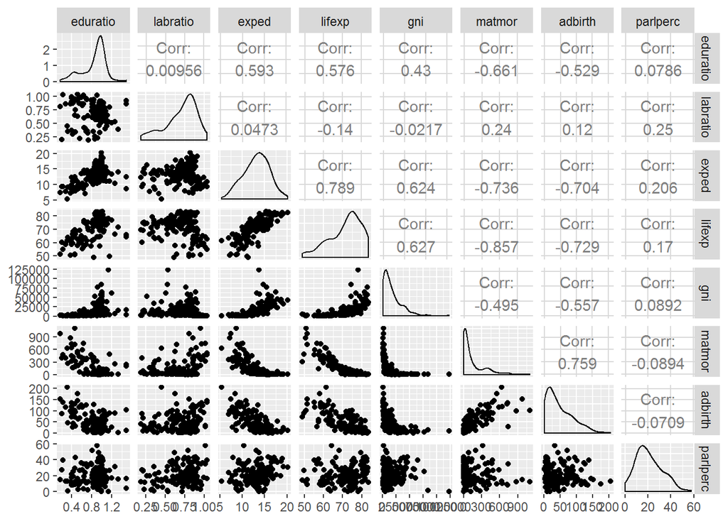

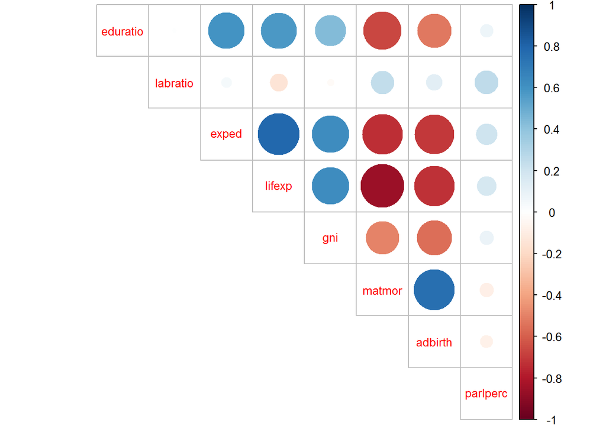

## Principal Component Analysis with Non-Standardized Data

First we shall conduct a Principal Component Analysis (PCA) using the same data as above with non-standardized variables.

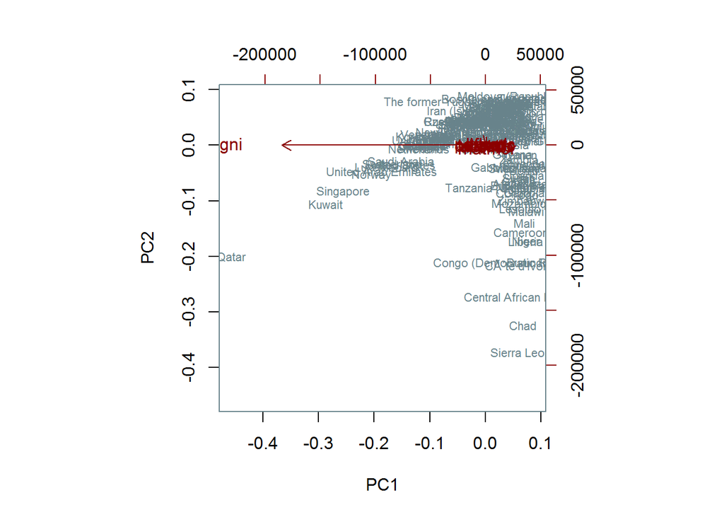

As seen in the biplot visualisation above, GNI clearly stands out from the other variables. However, this is due to this variable being numerically on a completely different scale than the other variable values, tens of thousands vs. <1 or <100% ratios. This causes the correlation to be unreliable (with only outliers showing) not to mention difficult to analyse. The data must thus be scaled.

## Principal Component Analysis with Standardized Data

To amend for the abovementioned problem, we must conduct a PCA using a standardized set of the data, where mean = 0 and standard deviation 1. The results are visualised using PC1 and PC2, along with the percentages of explained variance for both principal components. Together the components explain 69.8 of the variance.

```
##     eduratio          labratio           exped             lifexp
##  Min.   :-2.8189   Min.   :-2.6247   Min.   :-2.7378   Min.   :-2.7188
##  1st Qu.:-0.5233   1st Qu.:-0.5484   1st Qu.:-0.6782   1st Qu.:-0.6425
##  Median : 0.3503   Median : 0.2316   Median : 0.1140   Median : 0.3056
##  Mean   : 0.0000   Mean   : 0.0000   Mean   : 0.0000   Mean   : 0.0000
##  3rd Qu.: 0.5958   3rd Qu.: 0.7350   3rd Qu.: 0.7126   3rd Qu.: 0.6717
##  Max.   : 2.6646   Max.   : 1.6632   Max.   : 2.4730   Max.   : 1.4218
##       gni              matmor           adbirth           parlperc
##  Min.   :-0.9193   Min.   :-0.6992   Min.   :-1.1325   Min.   :-1.8203
##  1st Qu.:-0.7243   1st Qu.:-0.6496   1st Qu.:-0.8394   1st Qu.:-0.7409
##  Median :-0.3013   Median :-0.4726   Median :-0.3298   Median :-0.1403
##  Mean   : 0.0000   Mean   : 0.0000   Mean   : 0.0000   Mean   : 0.0000
##  3rd Qu.: 0.3712   3rd Qu.: 0.1932   3rd Qu.: 0.6030   3rd Qu.: 0.6127
##  Max.   : 5.6890   Max.   : 4.4899   Max.   : 3.8344   Max.   : 3.1850
```

```
## [1] "PC1 (53.6%)" "PC2 (16.2%)" "PC3 (9.6%)"  "PC4 (7.6%)"  "PC5 (5.5%)"
## [6] "PC6 (3.6%)"  "PC7 (2.6%)"  "PC8 (1.3%)"
```

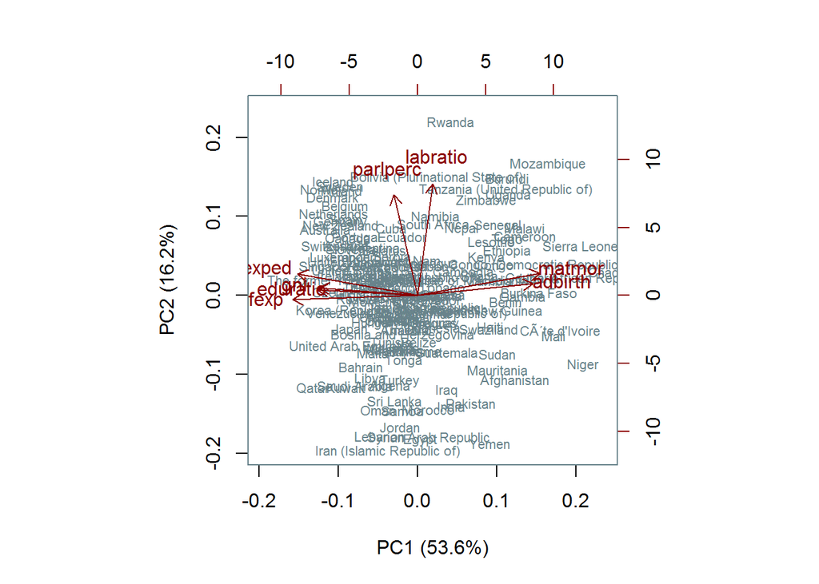

From this biplot we can see that expected level of education correlates - expectedly - with the ratio of percentages of females vs. males with secondary education as well as gni and life expectancy at birth. Further, these four variables correlate negatively with maternal mortality and adolescent birth rate. We also see that the ratio of percentages of females vs males in labour correlates with the percentage of female representatives in the parliament.

## Interpretations

I interpret the two principal components identified above as follows:

- PC1: life and welfare
- PC2: representation

Along PC1 (53.6% of variation) we have variables that represent life and mortality, but also education and gni, Meanwhile, PC2 (16.2% of variation) represents two variables tied to the representation of females in worklife and politics. Female representation alone does not guarantee low maternal mortality or adolescent birth rate (cf. Mozambique in biplot above), but high education levels or gni also do not guarantee equal representation (cf. Iran or Qatar)

[figure not shown]

# Multiple Correspondence Analysis

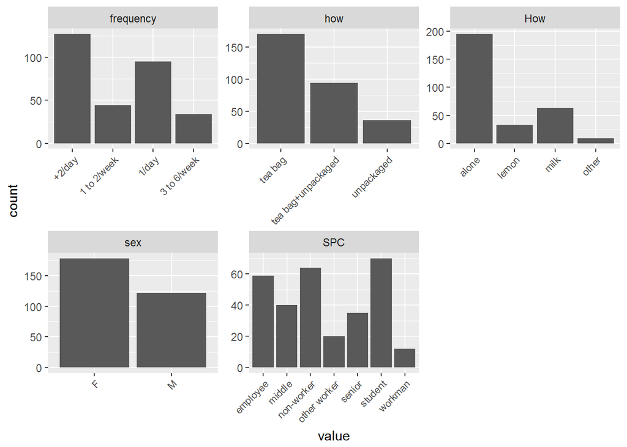

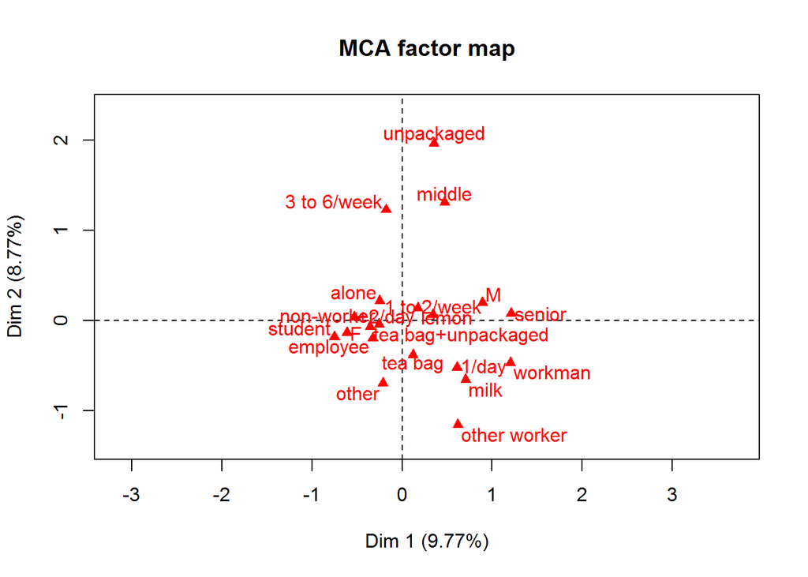

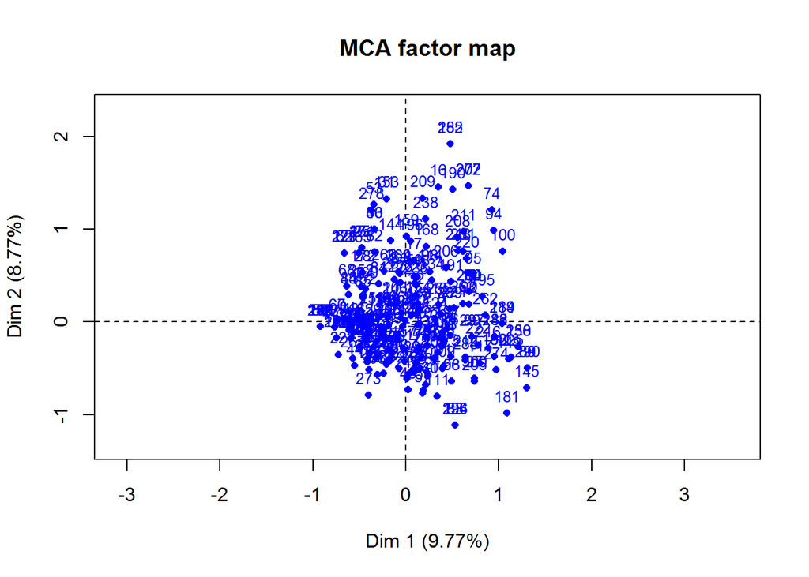

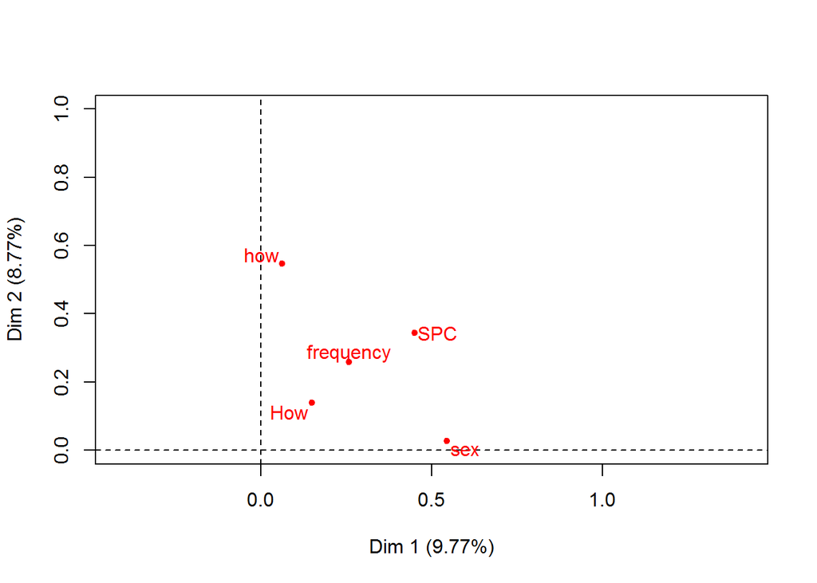

```
##
## Call:
## MCA(X = tea2)
##
##
## Eigenvalues
##                        Dim.1   Dim.2   Dim.3   Dim.4   Dim.5   Dim.6
## Variance               0.293   0.263   0.248   0.243   0.233   0.221
## % of var.              9.772   8.766   8.268   8.085   7.774   7.357
## Cumulative % of var.   9.772  18.537  26.806  34.891  42.665  50.021
##                        Dim.7   Dim.8   Dim.9  Dim.10  Dim.11  Dim.12
## Variance               0.208   0.197   0.191   0.183   0.166   0.159
## % of var.              6.936   6.553   6.382   6.103   5.517   5.306
## Cumulative % of var.  56.957  63.509  69.891  75.994  81.511  86.817
##                       Dim.13  Dim.14  Dim.15
## Variance               0.139   0.129   0.128
## % of var.              4.618   4.312   4.253
## Cumulative % of var.  91.435  95.747 100.000
##
## Individuals (the 10 first)
##                 Dim.1    ctr   cos2    Dim.2    ctr   cos2    Dim.3    ctr
## 1            |  0.683  0.530  0.204 |  0.325  0.133  0.046 | -0.369  0.183
## 2            |  0.480  0.262  0.083 | -0.147  0.027  0.008 | -0.360  0.174
## 3            | -0.240  0.065  0.017 | -0.551  0.385  0.087 | -0.611  0.501
## 4            |  0.231  0.061  0.033 | -0.259  0.085  0.041 | -0.370  0.184
## 5            | -0.033  0.001  0.001 | -0.047  0.003  0.001 |  0.060  0.005
## 6            |  0.231  0.061  0.033 | -0.259  0.085  0.041 | -0.370  0.184
## 7            |  0.665  0.502  0.122 |  0.526  0.351  0.076 |  0.502  0.339
## 8            |  0.381  0.165  0.041 |  0.080  0.008  0.002 | -0.739  0.733
## 9            |  0.712  0.576  0.155 | -0.159  0.032  0.008 |  1.220  2.002
## 10           |  0.359  0.147  0.049 |  0.183  0.042  0.013 |  1.131  1.720
##                cos2
## 1             0.060 |
## 2             0.047 |
## 3             0.107 |
## 4             0.084 |
## 5             0.002 |
## 6             0.084 |
## 7             0.069 |
## 8             0.156 |
```

[output cut: 19 more lines]

```
## other worker -1.094  6.428  0.085 -5.054 |
## senior        1.486 20.786  0.292  9.341 |
## student      -0.374  2.626  0.042 -3.564 |
## workman       0.058  0.011  0.000  0.204 |
## 1/day        -0.034  0.029  0.001 -0.395 |
## 1 to 2/week  -0.976 11.275  0.164 -7.000 |
## +2/day        0.289  2.845  0.061  4.278 |
##
## Categorical variables (eta2)
##                Dim.1 Dim.2 Dim.3
## SPC          | 0.451 0.344 0.424 |
## frequency    | 0.258 0.258 0.184 |
## how          | 0.063 0.547 0.521 |
## How          | 0.149 0.139 0.102 |
## sex          | 0.546 0.027 0.010 |
```

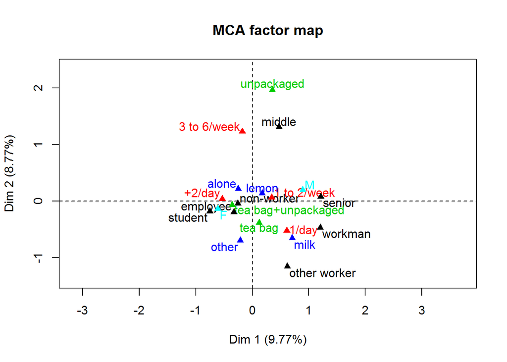

We need up to 6 dimensions to be able to explain even 50 % of the variance. However, it appears for example that the middle class favours unpackaged (loose leaf) tea above other society groups. Further, they do not drink tea with milk as much as the working class. (It is known in sociology that the middle class tends to distinguish itself from lower classes but that their practices differ from those of upper classes.) Raising concerns about the data is that students and females seem to have strong correlation, whereas senior correlates with male. This could indicate a data sampling where a sex is overrepresented in a group. However, investigating the data further falls outside the scope of the current analysis.